# SPSS_Output_hmwk5Key

[output not shown]

Log  
Log - Log - November 15, 2017

GET  
FILE='C:\MyGithub\N736Fall2017_Homework5Key\helpmkh.sav'.  
DATASET NAME DataSet1 WINDOW=FRONT.  
* Encoding: UTF-8.  
* ============================================.  
* N736 Homework 5: Analysis of Covariance (ANCOVA)  
*  
* by Melinda Higgins, PhD  
* dated November 13, 2017  
* ============================================.  
* ============================================.  
* For this Homework 5 we will be working with the HELP dataset  
* load helpmkh.sav  
* ============================================.  
* ============================================.  
* We will be working with these variables from the HELP dataset  
* indtot, mcs, pss_fr and female  
*  
* Run descriptive statistics on these variables  
* ============================================.  
FREQUENCIES VARIABLES=indtot mcs pss_fr female  
/NTILES=4  
/STATISTICS=STDDEV MINIMUM MAXIMUM MEAN  
/HISTOGRAM  
/ORDER=ANALYSIS.

Frequencies  
Frequencies - Active Dataset - November 15, 2017

[DataSet1] C:\MyGithub\N736Fall2017_Homework5Key\helpmkh.sav

Frequencies  
Frequencies - Statistics - November 15, 2017

StatisticsStatistics, table, 1 levels of column headers and 2 levels of row headers, table with 6 columns and 11 rows

|  |  | indtot Inventory of Drug Use Consequences (InDue) total score - Baseline | mcs SF36 Mental Composite Score - Baseline | pss_fr Perceived Social Support - friends | female Gender of respondent |
| --- | --- | --- | --- | --- | --- |
| N | Valid | 453 | 453 | 453 | 453 |
|  | Missing | 0 | 0 | 0 | 0 |
| Mean |  | 35.73 | 31.676678300693336 | 6.71 | .24 |
| Std. Deviation |  | 7.152 | 12.839337307517008 | 3.995 | .425 |
| Minimum |  | 4 | 6.76292324066162 | 0 | 0 |
| Maximum |  | 45 | 62.17550277709960 | 14 | 1 |
| Percentiles | 25 | 32.00 | 21.672114372253400 | 3.00 | .00 |
|  | 50 | 38.00 | 28.602416992187500 | 7.00 | .00 |
|  | 75 | 41.00 | 40.975919723510750 | 10.00 | .00 |

Frequency Table  
Frequency Table - indtot Inventory of Drug Use Consequences (InDue) total score - Baseline - Novembe(more)r 15, 2017(less)

indtot Inventory of Drug Use Consequences (InDue) total score - Baselineindtot Inventory of Drug Use Consequences (InDue) total score - Baseline, table, 1 levels of column headers and 2 levels of row headers, table with 6 columns and 41 rows

|  |  | Frequency | Percent | Valid Percent | Cumulative Percent |
| --- | --- | --- | --- | --- | --- |
| Valid | 4 | 1 | .2 | .2 | .2 |
|  | 6 | 1 | .2 | .2 | .4 |
|  | 8 | 1 | .2 | .2 | .7 |
|  | 9 | 1 | .2 | .2 | .9 |
|  | 10 | 1 | .2 | .2 | 1.1 |
|  | 11 | 1 | .2 | .2 | 1.3 |
|  | 12 | 1 | .2 | .2 | 1.5 |
|  | 13 | 2 | .4 | .4 | 2.0 |
|  | 14 | 1 | .2 | .2 | 2.2 |
|  | 15 | 2 | .4 | .4 | 2.6 |
|  | 17 | 1 | .2 | .2 | 2.9 |
|  | 19 | 5 | 1.1 | 1.1 | 4.0 |
|  | 20 | 3 | .7 | .7 | 4.6 |
|  | 21 | 4 | .9 | .9 | 5.5 |
|  | 22 | 3 | .7 | .7 | 6.2 |
|  | 23 | 2 | .4 | .4 | 6.6 |
|  | 24 | 1 | .2 | .2 | 6.8 |
|  | 25 | 6 | 1.3 | 1.3 | 8.2 |
|  | 26 | 5 | 1.1 | 1.1 | 9.3 |
|  | 27 | 5 | 1.1 | 1.1 | 10.4 |
|  | 28 | 11 | 2.4 | 2.4 | 12.8 |
|  | 29 | 16 | 3.5 | 3.5 | 16.3 |
|  | 30 | 8 | 1.8 | 1.8 | 18.1 |
|  | 31 | 16 | 3.5 | 3.5 | 21.6 |
|  | 32 | 20 | 4.4 | 4.4 | 26.0 |
|  | 33 | 19 | 4.2 | 4.2 | 30.2 |
|  | 34 | 19 | 4.2 | 4.2 | 34.4 |
|  | 35 | 17 | 3.8 | 3.8 | 38.2 |
|  | 36 | 25 | 5.5 | 5.5 | 43.7 |
|  | 37 | 28 | 6.2 | 6.2 | 49.9 |
|  | 38 | 33 | 7.3 | 7.3 | 57.2 |
|  | 39 | 28 | 6.2 | 6.2 | 63.4 |
|  | 40 | 37 | 8.2 | 8.2 | 71.5 |
|  | 41 | 39 | 8.6 | 8.6 | 80.1 |
|  | 42 | 34 | 7.5 | 7.5 | 87.6 |
|  | 43 | 26 | 5.7 | 5.7 | 93.4 |
|  | 44 | 25 | 5.5 | 5.5 | 98.9 |
|  | 45 | 5 | 1.1 | 1.1 | 100.0 |
|  | Total | 453 | 100.0 | 100.0 |  |

Frequency Table  
Frequency Table - mcs SF36 Mental Composite Score - Baseline - November 15, 2017

mcs SF36 Mental Composite Score - Baselinemcs SF36 Mental Composite Score - Baseline, table, 1 levels of column headers and 2 levels of row headers, table with 6 columns and 456 rows

[output not shown]

[output cut: 425 more lines]

Frequency Table  
Frequency Table - pss_fr Perceived Social Support - friends - November 15, 2017

pss_fr Perceived Social Support - friendspss_fr Perceived Social Support - friends, table, 1 levels of column headers and 2 levels of row headers, table with 6 columns and 18 rows

|  |  | Frequency | Percent | Valid Percent | Cumulative Percent |
| --- | --- | --- | --- | --- | --- |
| Valid | 0 | 14 | 3.1 | 3.1 | 3.1 |
|  | 1 | 34 | 7.5 | 7.5 | 10.6 |
|  | 2 | 32 | 7.1 | 7.1 | 17.7 |
|  | 3 | 45 | 9.9 | 9.9 | 27.6 |
|  | 4 | 34 | 7.5 | 7.5 | 35.1 |
|  | 5 | 37 | 8.2 | 8.2 | 43.3 |
|  | 6 | 29 | 6.4 | 6.4 | 49.7 |
|  | 7 | 38 | 8.4 | 8.4 | 58.1 |
|  | 8 | 29 | 6.4 | 6.4 | 64.5 |
|  | 9 | 26 | 5.7 | 5.7 | 70.2 |
|  | 10 | 29 | 6.4 | 6.4 | 76.6 |
|  | 11 | 40 | 8.8 | 8.8 | 85.4 |
|  | 12 | 30 | 6.6 | 6.6 | 92.1 |
|  | 13 | 16 | 3.5 | 3.5 | 95.6 |
|  | 14 | 20 | 4.4 | 4.4 | 100.0 |
|  | Total | 453 | 100.0 | 100.0 |  |

Frequency Table  
Frequency Table - female Gender of respondent - November 15, 2017

female Gender of respondentfemale Gender of respondent, table, 1 levels of column headers and 2 levels of row headers, table with 6 columns and 5 rows

|  |  | Frequency | Percent | Valid Percent | Cumulative Percent |
| --- | --- | --- | --- | --- | --- |
| Valid | 0 Male | 346 | 76.4 | 76.4 | 76.4 |
|  | 1 Female | 107 | 23.6 | 23.6 | 100.0 |
|  | Total | 453 | 100.0 | 100.0 |  |

Histogram  
Histogram - Inventory of Drug Use Consequences (InDue) total score - Baseline - November 15, 2017

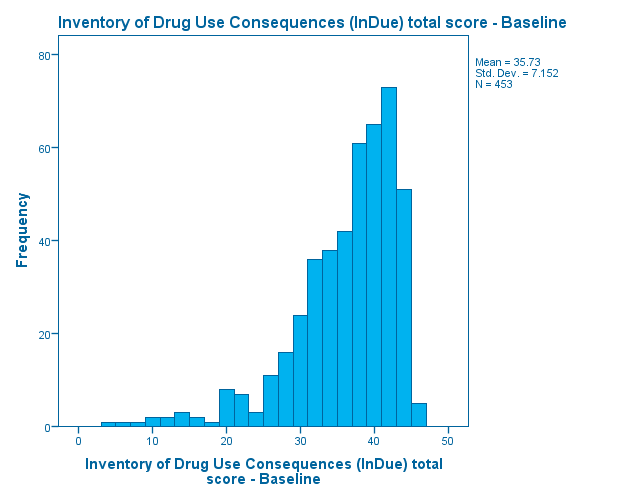

Histogram  
Histogram - SF36 Mental Composite Score - Baseline - November 15, 2017

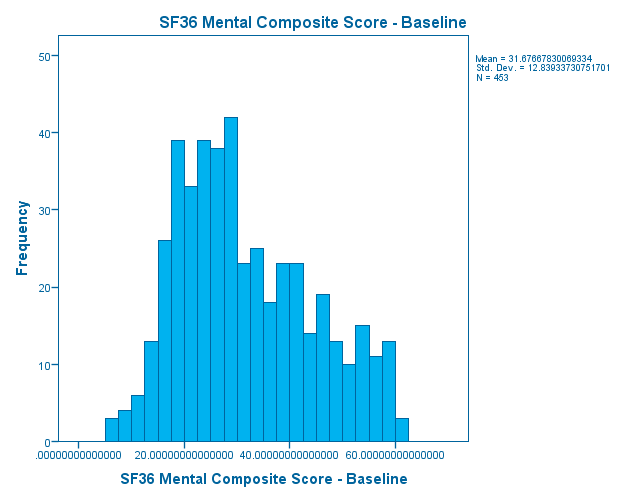

Histogram  
Histogram - Perceived Social Support - friends - November 15, 2017

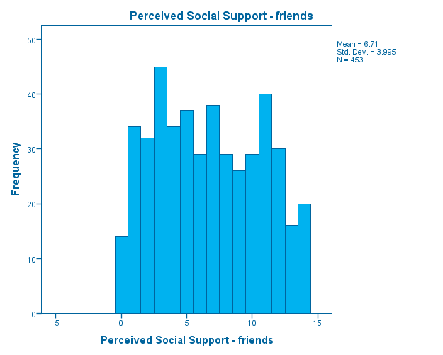

Histogram  
Histogram - Gender of respondent - November 15, 2017

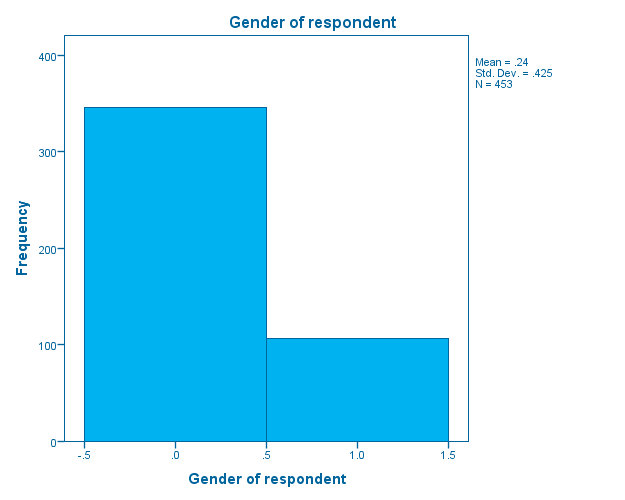

Log  
Log - Log - November 15, 2017

* ============================================.  
* Let's also look at the correlation matrix  
* ============================================.  
CORRELATIONS  
/VARIABLES=indtot mcs pss_fr female  
/PRINT=TWOTAIL NOSIG  
/MISSING=PAIRWISE.

Correlations  
Correlations - Correlations - November 15, 2017

CorrelationsCorrelations, table, 1 levels of column headers and 2 levels of row headers, table with 6 columns and 16 rows

|  |  | indtot Inventory of Drug Use Consequences (InDue) total score - Baseline | mcs SF36 Mental Composite Score - Baseline | pss_fr Perceived Social Support - friends | female Gender of respondent |
| --- | --- | --- | --- | --- | --- |
| indtot Inventory of Drug Use Consequences (InDue) total score - Baseline | Pearson Correlation | 1 | -.381** | -.198** | -.261** |
|  | Sig. (2-tailed) |  | .000 | .000 | .000 |
|  | N | 453 | 453 | 453 | 453 |
| mcs SF36 Mental Composite Score - Baseline | Pearson Correlation | -.381** | 1 | .138** | -.119* |
|  | Sig. (2-tailed) | .000 |  | .003 | .011 |
|  | N | 453 | 453 | 453 | 453 |
| pss_fr Perceived Social Support - friends | Pearson Correlation | -.198** | .138** | 1 | .067 |
|  | Sig. (2-tailed) | .000 | .003 |  | .155 |
|  | N | 453 | 453 | 453 | 453 |
| female Gender of respondent | Pearson Correlation | -.261** | -.119* | .067 | 1 |
|  | Sig. (2-tailed) | .000 | .011 | .155 |  |
|  | N | 453 | 453 | 453 | 453 |

**. Correlation is significant at the 0.01 level (2-tailed).  
*. Correlation is significant at the 0.05 level (2-tailed).

Log  
Log - Log - November 15, 2017

NONPAR CORR  
/VARIABLES=indtot mcs pss_fr female  
/PRINT=SPEARMAN TWOTAIL NOSIG  
/MISSING=PAIRWISE.

Nonparametric Correlations  
Nonparametric Correlations - Correlations - November 15, 2017

CorrelationsCorrelations, table, 1 levels of column headers and 3 levels of row headers, table with 7 columns and 16 rows

|  |  |  | indtot Inventory of Drug Use Consequences (InDue) total score - Baseline | mcs SF36 Mental Composite Score - Baseline | pss_fr Perceived Social Support - friends | female Gender of respondent |
| --- | --- | --- | --- | --- | --- | --- |
| Spearman's rho | indtot Inventory of Drug Use Consequences (InDue) total score - Baseline | Correlation Coefficient | 1.000 | -.343** | -.185** | -.258** |
|  |  | Sig. (2-tailed) | . | .000 | .000 | .000 |
|  |  | N | 453 | 453 | 453 | 453 |
|  | mcs SF36 Mental Composite Score - Baseline | Correlation Coefficient | -.343** | 1.000 | .126** | -.121* |
|  |  | Sig. (2-tailed) | .000 | . | .007 | .010 |
|  |  | N | 453 | 453 | 453 | 453 |
|  | pss_fr Perceived Social Support - friends | Correlation Coefficient | -.185** | .126** | 1.000 | .063 |
|  |  | Sig. (2-tailed) | .000 | .007 | . | .178 |
|  |  | N | 453 | 453 | 453 | 453 |
|  | female Gender of respondent | Correlation Coefficient | -.258** | -.121* | .063 | 1.000 |
|  |  | Sig. (2-tailed) | .000 | .010 | .178 | . |
|  |  | N | 453 | 453 | 453 | 453 |

**. Correlation is significant at the 0.01 level (2-tailed).  
*. Correlation is significant at the 0.05 level (2-tailed).

Log  
Log - Log - November 15, 2017

* ============================================.  
* We will be treating pss_fr and female as covariates  
* We will also be interested in the interaction between  
* mcs and female and between mcs and pss_fr  
* so, let's mean center mcs and pss_fr and then create  
* interaction variables mcsC-x-pss_frC and mcsC-x-female  
*  
* The mean of mcs = 31.677  
* The mean of pss_fr = 6.71  
*  
* We will also be exploring the affect of the contrast comparison  
* tests run for gender and the default handling of 0,1 coding  
* so, let's also code a variable "male" which is the reverse coding  
* of "female".  
* ============================================.  
compute male = female=0.  
compute mcsC = mcs - 31.677.  
compute pss_frC = pss_fr - 6.71.  
compute mcsC_x_pss_frC = mcsC * pss_frC.  
compute mcsC_x_female = mcsC * female.  
compute mcsC_x_male = mcsC * male.  
execute.  
* ============================================.  
* ANCOVA using a regression approach  
* DV = indtot; IV = mcs; CV = pss_fr  
*  
* put in main effect for mcsC  
* then add covariate pss_frC  
* and then test for homogenity of slopes - add in interaction term  
* ============================================.  
REGRESSION  
/DESCRIPTIVES MEAN STDDEV CORR SIG N  
/MISSING LISTWISE  
/STATISTICS COEFF OUTS CI(95) R ANOVA COLLIN TOL CHANGE ZPP  
/CRITERIA=PIN(.05) POUT(.10)  
/NOORIGIN  
/DEPENDENT indtot  
/METHOD=ENTER mcsC  
/METHOD=ENTER pss_frC  
/METHOD=ENTER mcsC_x_pss_frC  
/RESIDUALS HISTOGRAM(ZRESID) NORMPROB(ZRESID).

Regression  
Regression - Descriptive Statistics - November 15, 2017

Descriptive StatisticsDescriptive Statistics, table, 1 levels of column headers and 1 levels of row headers, table with 4 columns and 6 rows

|  | Mean | Std. Deviation | N |
| --- | --- | --- | --- |
| indtot Inventory of Drug Use Consequences (InDue) total score - Baseline | 35.73 | 7.152 | 453 |
| mcsC | -.0003 | 12.83934 | 453 |
| pss_frC | -.0036 | 3.99501 | 453 |
| mcsC_x_pss_frC | 7.0562 | 53.68474 | 453 |

Regression  
Regression - Correlations - November 15, 2017

CorrelationsCorrelations, table, 1 levels of column headers and 2 levels of row headers, table with 6 columns and 14 rows

|  |  | indtot Inventory of Drug Use Consequences (InDue) total score - Baseline | mcsC | pss_frC | mcsC_x_pss_frC |
| --- | --- | --- | --- | --- | --- |
| Pearson Correlation | indtot Inventory of Drug Use Consequences (InDue) total score - Baseline | 1.000 | -.381 | -.198 | -.075 |
|  | mcsC | -.381 | 1.000 | .138 | .167 |
|  | pss_frC | -.198 | .138 | 1.000 | .058 |
|  | mcsC_x_pss_frC | -.075 | .167 | .058 | 1.000 |
| Sig. (1-tailed) | indtot Inventory of Drug Use Consequences (InDue) total score - Baseline | . | .000 | .000 | .055 |
|  | mcsC | .000 | . | .002 | .000 |
|  | pss_frC | .000 | .002 | . | .108 |
|  | mcsC_x_pss_frC | .055 | .000 | .108 | . |
| N | indtot Inventory of Drug Use Consequences (InDue) total score - Baseline | 453 | 453 | 453 | 453 |
|  | mcsC | 453 | 453 | 453 | 453 |
|  | pss_frC | 453 | 453 | 453 | 453 |
|  | mcsC_x_pss_frC | 453 | 453 | 453 | 453 |

Regression  
Regression - Variables Entered/Removed - November 15, 2017

Variables Entered/Removed<sup>a</sup>Variables Entered/Removed, table, 1 levels of column headers and 1 levels of row headers, table with 4 columns and 7 rows

| Model | Variables Entered | Variables Removed | Method |
| --- | --- | --- | --- |
| 1 | mcsC<sup>b</sup> | . | Enter |
| 2 | pss_frC<sup>b</sup> | . | Enter |
| 3 | mcsC_x_pss_frC<sup>b</sup> | . | Enter |

a. Dependent Variable: indtot Inventory of Drug Use Consequences (InDue) total score - Baseline  
b. All requested variables entered.

Regression  
Regression - Model Summary - November 15, 2017

Model Summary<sup>d</sup>Model Summary, table, 2 levels of column headers and 1 levels of row headers, table with 10 columns and 10 rows

| Model | R | R Square | Adjusted R Square | Std. Error of the Estimate | Change Statistics |  |  |  |  |
| --- | --- | --- | --- | --- | --- | --- | --- | --- | --- |
|  |  |  |  |  | R Square Change | F Change | df1 | df2 | Sig. F Change |
| 1 | .381<sup>a</sup> | .145 | .143 | 6.621 | .145 | 76.407 | 1 | 451 | .000 |
| 2 | .408<sup>b</sup> | .166 | .163 | 6.545 | .021 | 11.603 | 1 | 450 | .001 |
| 3 | .408<sup>c</sup> | .166 | .161 | 6.552 | .000 | .025 | 1 | 449 | .874 |

a. Predictors: (Constant), mcsC  
b. Predictors: (Constant), mcsC, pss_frC  
c. Predictors: (Constant), mcsC, pss_frC, mcsC_x_pss_frC  
d. Dependent Variable: indtot Inventory of Drug Use Consequences (InDue) total score - Baseline

Regression  
Regression - ANOVA - November 15, 2017

ANOVA<sup>a</sup>ANOVA, table, 1 levels of column headers and 2 levels of row headers, table with 7 columns and 15 rows

| Model |  | Sum of Squares | df | Mean Square | F | Sig. |
| --- | --- | --- | --- | --- | --- | --- |
| 1 | Regression | 3349.702 | 1 | 3349.702 | 76.407 | .000<sup>b</sup> |
|  | Residual | 19771.900 | 451 | 43.840 |  |  |
|  | Total | 23121.603 | 452 |  |  |  |
| 2 | Regression | 3846.682 | 2 | 1923.341 | 44.903 | .000<sup>c</sup> |
|  | Residual | 19274.920 | 450 | 42.833 |  |  |
|  | Total | 23121.603 | 452 |  |  |  |
| 3 | Regression | 3847.759 | 3 | 1282.586 | 29.879 | .000<sup>d</sup> |
|  | Residual | 19273.843 | 449 | 42.926 |  |  |
|  | Total | 23121.603 | 452 |  |  |  |

a. Dependent Variable: indtot Inventory of Drug Use Consequences (InDue) total score - Baseline  
b. Predictors: (Constant), mcsC  
c. Predictors: (Constant), mcsC, pss_frC  
d. Predictors: (Constant), mcsC, pss_frC, mcsC_x_pss_frC

Regression  
Regression - Coefficients - November 15, 2017

Coefficients<sup>a</sup>Coefficients, table, 2 levels of column headers and 2 levels of row headers, table with 14 columns and 13 rows

| Model |  | Unstandardized Coefficients |  | Standardized Coefficients | t | Sig. | 95.0% Confidence Interval for B |  | Correlations |  |  | Collinearity Statistics |  |
| --- | --- | --- | --- | --- | --- | --- | --- | --- | --- | --- | --- | --- | --- |
|  |  | B | Std. Error | Beta |  |  | Lower Bound | Upper Bound | Zero-order | Partial | Part | Tolerance | VIF |
| 1 | (Constant) | 35.728 | .311 |  | 114.849 | .000 | 35.117 | 36.340 |  |  |  |  |  |
|  | mcsC | -.212 | .024 | -.381 | -8.741 | .000 | -.260 | -.164 | -.381 | -.381 | -.381 | 1.000 | 1.000 |
| 2 | (Constant) | 35.727 | .307 |  | 116.188 | .000 | 35.123 | 36.332 |  |  |  |  |  |
|  | mcsC | -.201 | .024 | -.360 | -8.289 | .000 | -.248 | -.153 | -.381 | -.364 | -.357 | .981 | 1.019 |
|  | pss_frC | -.265 | .078 | -.148 | -3.406 | .001 | -.418 | -.112 | -.198 | -.159 | -.147 | .981 | 1.019 |
| 3 | (Constant) | 35.734 | .311 |  | 115.061 | .000 | 35.124 | 36.344 |  |  |  |  |  |
|  | mcsC | -.200 | .025 | -.359 | -8.147 | .000 | -.248 | -.152 | -.381 | -.359 | -.351 | .956 | 1.046 |
|  | pss_frC | -.265 | .078 | -.148 | -3.395 | .001 | -.418 | -.111 | -.198 | -.158 | -.146 | .980 | 1.021 |
|  | mcsC_x_pss_frC | -.001 | .006 | -.007 | -.158 | .874 | -.012 | .011 | -.075 | -.007 | -.007 | .971 | 1.030 |

a. Dependent Variable: indtot Inventory of Drug Use Consequences (InDue) total score - Baseline

Regression  
Regression - Excluded Variables - November 15, 2017

Excluded Variables<sup>a</sup>Excluded Variables, table, 2 levels of column headers and 2 levels of row headers, table with 9 columns and 9 rows

| Model |  | Beta In | t | Sig. | Partial Correlation | Collinearity Statistics |  |  |
| --- | --- | --- | --- | --- | --- | --- | --- | --- |
|  |  |  |  |  |  | Tolerance | VIF | Minimum Tolerance |
| 1 | pss_frC | -.148<sup>b</sup> | -3.406 | .001 | -.159 | .981 | 1.019 | .981 |
|  | mcsC_x_pss_frC | -.012<sup>b</sup> | -.278 | .781 | -.013 | .972 | 1.029 | .972 |
| 2 | mcsC_x_pss_frC | -.007<sup>c</sup> | -.158 | .874 | -.007 | .971 | 1.030 | .956 |

a. Dependent Variable: indtot Inventory of Drug Use Consequences (InDue) total score - Baseline  
b. Predictors in the Model: (Constant), mcsC  
c. Predictors in the Model: (Constant), mcsC, pss_frC

Regression  
Regression - Collinearity Diagnostics - November 15, 2017

Collinearity Diagnostics<sup>a</sup>Collinearity Diagnostics, table, 2 levels of column headers and 2 levels of row headers, table with 8 columns and 13 rows

| Model | Dimension | Eigenvalue | Condition Index | Variance Proportions |  |  |  |
| --- | --- | --- | --- | --- | --- | --- | --- |
|  |  |  |  | (Constant) | mcsC | pss_frC | mcsC_x_pss_frC |
| 1 | 1 | 1.000 | 1.000 | .50 | .50 |  |  |
|  | 2 | 1.000 | 1.000 | .50 | .50 |  |  |
| 2 | 1 | 1.138 | 1.000 | .00 | .43 | .43 |  |
|  | 2 | 1.000 | 1.067 | 1.00 | .00 | .00 |  |
|  | 3 | .862 | 1.149 | .00 | .57 | .57 |  |
| 3 | 1 | 1.268 | 1.000 | .07 | .27 | .15 | .28 |
|  | 2 | 1.054 | 1.097 | .52 | .09 | .23 | .09 |
|  | 3 | .897 | 1.189 | .23 | .16 | .56 | .14 |
|  | 4 | .781 | 1.274 | .18 | .48 | .06 | .50 |

a. Dependent Variable: indtot Inventory of Drug Use Consequences (InDue) total score - Baseline

Regression  
Regression - Residuals Statistics - November 15, 2017

Residuals Statistics<sup>a</sup>Residuals Statistics, table, 1 levels of column headers and 1 levels of row headers, table with 6 columns and 7 rows

|  | Minimum | Maximum | Mean | Std. Deviation | N |
| --- | --- | --- | --- | --- | --- |
| Predicted Value | 28.06 | 40.90 | 35.73 | 2.918 | 453 |
| Residual | -26.836 | 12.361 | .000 | 6.530 | 453 |
| Std. Predicted Value | -2.628 | 1.772 | .000 | 1.000 | 453 |
| Std. Residual | -4.096 | 1.887 | .000 | .997 | 453 |

a. Dependent Variable: indtot Inventory of Drug Use Consequences (InDue) total score - Baseline

Charts  
Charts - *zresid Histogram - November 15, 2017

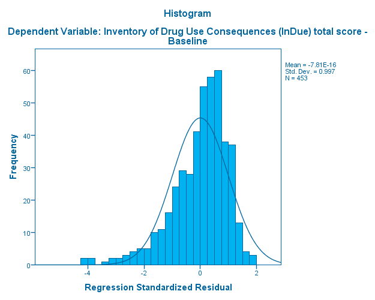

Charts  
Charts - *zresid Normal P-P Plot - November 15, 2017

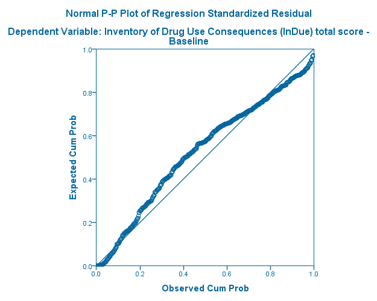

Log  
Log - Log - November 15, 2017

* ============================================.  
* ANCOVA using ANOVA approach  
* ============================================.  
UNIANOVA indtot WITH mcsC pss_frC  
/METHOD=SSTYPE(3)  
/INTERCEPT=INCLUDE  
/PRINT=PARAMETER ETASQ HOMOGENEITY DESCRIPTIVE  
/CRITERIA=ALPHA(.05)  
/DESIGN=mcsC pss_frC mcsC*pss_frC.

Univariate Analysis of Variance  
Univariate Analysis of Variance - Warnings - November 15, 2017

WarningsWarnings, table, 0 levels of column headers and 0 levels of row headers, table with 1 columns and 2 rows

| The HOMOGENEITY specification in the PRINT subcommand will be ignored because there are no between-subjects factors. |
| --- |

Univariate Analysis of Variance  
Univariate Analysis of Variance - Descriptive Statistics - November 15, 2017

Descriptive StatisticsDescriptive Statistics, table, Dependent Variable, indtot Inventory of Drug Use Consequences (InDue) total score - Baseline, 1 layers, 1 levels of column headers and 0 levels of row headers, table with 3 columns and 4 rows

| indtot Inventory of Drug Use Consequences (InDue) total score - Baseline indtot Inventory of Drug Use Consequences (InDue) total score - Baseline |  |  |
| --- | --- | --- |
| Mean | Std. Deviation | N |
| 35.73 | 7.152 | 453 |

Univariate Analysis of Variance  
Univariate Analysis of Variance - Tests of Between-Subjects Effects - November 15, 2017

Tests of Between-Subjects EffectsTests of Between-Subjects Effects, table, Dependent Variable, indtot Inventory of Drug Use Consequences (InDue) total score - Baseline, 1 layers, 1 levels of column headers and 1 levels of row headers, table with 7 columns and 12 rows

| indtot Inventory of Drug Use Consequences (InDue) total score - Baseline indtot Inventory of Drug Use Consequences (InDue) total score - Baseline |  |  |  |  |  |  |
| --- | --- | --- | --- | --- | --- | --- |
| Source | Type III Sum of Squares | df | Mean Square | F | Sig. | Partial Eta Squared |
| Corrected Model | 3847.759<sup>a</sup> | 3 | 1282.586 | 29.879 | .000 | .166 |
| Intercept | 568303.084 | 1 | 568303.084 | 13239.087 | .000 | .967 |
| mcsC | 2849.492 | 1 | 2849.492 | 66.381 | .000 | .129 |
| pss_frC | 494.666 | 1 | 494.666 | 11.524 | .001 | .025 |
| mcsC * pss_frC | 1.077 | 1 | 1.077 | .025 | .874 | .000 |
| Error | 19273.843 | 449 | 42.926 |  |  |  |
| Total | 601387.000 | 453 |  |  |  |  |
| Corrected Total | 23121.603 | 452 |  |  |  |  |

a. R Squared = .166 (Adjusted R Squared = .161)

Univariate Analysis of Variance  
Univariate Analysis of Variance - Parameter Estimates - November 15, 2017

Parameter EstimatesParameter Estimates, table, Dependent Variable, indtot Inventory of Drug Use Consequences (InDue) total score - Baseline, 1 layers, 2 levels of column headers and 1 levels of row headers, table with 8 columns and 8 rows

| indtot Inventory of Drug Use Consequences (InDue) total score - Baseline indtot Inventory of Drug Use Consequences (InDue) total score - Baseline |  |  |  |  |  |  |  |  |
| --- | --- | --- | --- | --- | --- | --- | --- | --- |
| Parameter | B | Std. Error | t | Sig. | 95% Confidence Interval |  | Partial Eta Squared |  |
|  |  |  |  |  | Lower Bound | Upper Bound |  |  |
| Intercept | 35.734 | .311 | 115.061 | .000 | 35.124 | 36.344 |  | .967 |
| mcsC | -.200 | .025 | -8.147 | .000 | -.248 | -.152 | .129 |  |
| pss_frC | -.265 | .078 | -3.395 | .001 | -.418 | -.111 | .025 |  |
| mcsC * pss_frC | -.001 | .006 | -.158 | .874 | -.012 | .011 | .000 |  |

Log  
Log - Log - November 15, 2017

* ============================================.  
* Make a plot of the potential interaction between  
* mcs and pss_fr  
* first let's split pss_fr into high and low categories using a median split  
* the median of pss_fr = 7.0  
* ============================================.  
compute pss_fr_gt7 = pss_fr > 7.  
execute.  
GRAPH  
/SCATTERPLOT(BIVAR)=mcs WITH indtot  
/PANEL COLVAR=pss_fr_gt7 COLOP=CROSS  
/MISSING=LISTWISE.

Graph  
Graph - Scatter of indtot mcs - November 15, 2017

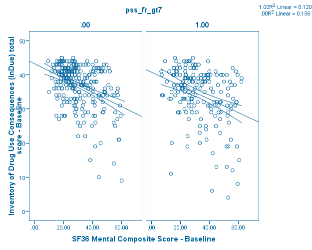

Log  
Log - Log - November 15, 2017

* ============================================.  
* double click on graph and click "elements/fit line to total"  
* to add a fit line for each group - the lines are close to parallel  
* ============================================.  
* ============================================.  
* ANCOVA using a regression approach  
* DV = indtot; IV = mcs; CV = female  
*  
* put in main effect for mcsC  
* then add covariate female  
* and then test for homogenity of slopes - add in interaction term  
* ============================================.  
REGRESSION  
/DESCRIPTIVES MEAN STDDEV CORR SIG N  
/MISSING LISTWISE  
/STATISTICS COEFF OUTS CI(95) R ANOVA COLLIN TOL CHANGE ZPP  
/CRITERIA=PIN(.05) POUT(.10)  
/NOORIGIN  
/DEPENDENT indtot  
/METHOD=ENTER mcsC  
/METHOD=ENTER female  
/METHOD=ENTER mcsC_x_female  
/RESIDUALS HISTOGRAM(ZRESID) NORMPROB(ZRESID).

Regression  
Regression - Descriptive Statistics - November 15, 2017

Descriptive StatisticsDescriptive Statistics, table, 1 levels of column headers and 1 levels of row headers, table with 4 columns and 6 rows

|  | Mean | Std. Deviation | N |
| --- | --- | --- | --- |
| indtot Inventory of Drug Use Consequences (InDue) total score - Baseline | 35.73 | 7.152 | 453 |
| mcsC | -.0003 | 12.83934 | 453 |
| female Gender of respondent | .24 | .425 | 453 |
| mcsC_x_female | -.6467 | 6.11965 | 453 |

Regression  
Regression - Correlations - November 15, 2017

CorrelationsCorrelations, table, 1 levels of column headers and 2 levels of row headers, table with 6 columns and 14 rows

|  |  | indtot Inventory of Drug Use Consequences (InDue) total score - Baseline | mcsC | female Gender of respondent | mcsC_x_female |
| --- | --- | --- | --- | --- | --- |
| Pearson Correlation | indtot Inventory of Drug Use Consequences (InDue) total score - Baseline | 1.000 | -.381 | -.261 | -.219 |
|  | mcsC | -.381 | 1.000 | -.119 | .482 |
|  | female Gender of respondent | -.261 | -.119 | 1.000 | -.190 |
|  | mcsC_x_female | -.219 | .482 | -.190 | 1.000 |
| Sig. (1-tailed) | indtot Inventory of Drug Use Consequences (InDue) total score - Baseline | . | .000 | .000 | .000 |
|  | mcsC | .000 | . | .006 | .000 |
|  | female Gender of respondent | .000 | .006 | . | .000 |
|  | mcsC_x_female | .000 | .000 | .000 | . |
| N | indtot Inventory of Drug Use Consequences (InDue) total score - Baseline | 453 | 453 | 453 | 453 |
|  | mcsC | 453 | 453 | 453 | 453 |
|  | female Gender of respondent | 453 | 453 | 453 | 453 |
|  | mcsC_x_female | 453 | 453 | 453 | 453 |

Regression  
Regression - Variables Entered/Removed - November 15, 2017

Variables Entered/Removed<sup>a</sup>Variables Entered/Removed, table, 1 levels of column headers and 1 levels of row headers, table with 4 columns and 7 rows

| Model | Variables Entered | Variables Removed | Method |
| --- | --- | --- | --- |
| 1 | mcsC<sup>b</sup> | . | Enter |
| 2 | female Gender of respondent<sup>b</sup> | . | Enter |
| 3 | mcsC_x_female<sup>b</sup> | . | Enter |

a. Dependent Variable: indtot Inventory of Drug Use Consequences (InDue) total score - Baseline  
b. All requested variables entered.

Regression  
Regression - Model Summary - November 15, 2017

Model Summary<sup>d</sup>Model Summary, table, 2 levels of column headers and 1 levels of row headers, table with 10 columns and 10 rows

| Model | R | R Square | Adjusted R Square | Std. Error of the Estimate | Change Statistics |  |  |  |  |
| --- | --- | --- | --- | --- | --- | --- | --- | --- | --- |
|  |  |  |  |  | R Square Change | F Change | df1 | df2 | Sig. F Change |
| 1 | .381<sup>a</sup> | .145 | .143 | 6.621 | .145 | 76.407 | 1 | 451 | .000 |
| 2 | .490<sup>b</sup> | .240 | .237 | 6.249 | .095 | 56.349 | 1 | 450 | .000 |
| 3 | .498<sup>c</sup> | .248 | .243 | 6.224 | .008 | 4.655 | 1 | 449 | .031 |

a. Predictors: (Constant), mcsC  
b. Predictors: (Constant), mcsC, female Gender of respondent  
c. Predictors: (Constant), mcsC, female Gender of respondent, mcsC_x_female  
d. Dependent Variable: indtot Inventory of Drug Use Consequences (InDue) total score - Baseline

Regression  
Regression - ANOVA - November 15, 2017

ANOVA<sup>a</sup>ANOVA, table, 1 levels of column headers and 2 levels of row headers, table with 7 columns and 15 rows

| Model |  | Sum of Squares | df | Mean Square | F | Sig. |
| --- | --- | --- | --- | --- | --- | --- |
| 1 | Regression | 3349.702 | 1 | 3349.702 | 76.407 | .000<sup>b</sup> |
|  | Residual | 19771.900 | 451 | 43.840 |  |  |
|  | Total | 23121.603 | 452 |  |  |  |
| 2 | Regression | 5550.014 | 2 | 2775.007 | 71.067 | .000<sup>c</sup> |
|  | Residual | 17571.589 | 450 | 39.048 |  |  |
|  | Total | 23121.603 | 452 |  |  |  |
| 3 | Regression | 5730.320 | 3 | 1910.107 | 49.314 | .000<sup>d</sup> |
|  | Residual | 17391.282 | 449 | 38.733 |  |  |
|  | Total | 23121.603 | 452 |  |  |  |

a. Dependent Variable: indtot Inventory of Drug Use Consequences (InDue) total score - Baseline  
b. Predictors: (Constant), mcsC  
c. Predictors: (Constant), mcsC, female Gender of respondent  
d. Predictors: (Constant), mcsC, female Gender of respondent, mcsC_x_female

Regression  
Regression - Coefficients - November 15, 2017

Coefficients<sup>a</sup>Coefficients, table, 2 levels of column headers and 2 levels of row headers, table with 14 columns and 13 rows

| Model |  | Unstandardized Coefficients |  | Standardized Coefficients | t | Sig. | 95.0% Confidence Interval for B |  | Correlations |  |  | Collinearity Statistics |  |
| --- | --- | --- | --- | --- | --- | --- | --- | --- | --- | --- | --- | --- | --- |
|  |  | B | Std. Error | Beta |  |  | Lower Bound | Upper Bound | Zero-order | Partial | Part | Tolerance | VIF |
| 1 | (Constant) | 35.728 | .311 |  | 114.849 | .000 | 35.117 | 36.340 |  |  |  |  |  |
|  | mcsC | -.212 | .024 | -.381 | -8.741 | .000 | -.260 | -.164 | -.381 | -.381 | -.381 | 1.000 | 1.000 |
| 2 | (Constant) | 36.963 | .337 |  | 109.843 | .000 | 36.301 | 37.624 |  |  |  |  |  |
|  | mcsC | -.233 | .023 | -.418 | -10.088 | .000 | -.278 | -.187 | -.381 | -.429 | -.415 | .986 | 1.014 |
|  | female Gender of respondent | -5.226 | .696 | -.311 | -7.507 | .000 | -6.594 | -3.858 | -.261 | -.334 | -.308 | .986 | 1.014 |
| 3 | (Constant) | 36.940 | .335 |  | 110.168 | .000 | 36.281 | 37.599 |  |  |  |  |  |
|  | mcsC | -.206 | .026 | -.370 | -7.916 | .000 | -.257 | -.155 | -.381 | -.350 | -.324 | .767 | 1.304 |
|  | female Gender of respondent | -5.457 | .702 | -.324 | -7.778 | .000 | -6.836 | -4.078 | -.261 | -.345 | -.318 | .963 | 1.039 |
|  | mcsC_x_female | -.119 | .055 | -.102 | -2.158 | .031 | -.228 | -.011 | -.219 | -.101 | -.088 | .750 | 1.334 |

a. Dependent Variable: indtot Inventory of Drug Use Consequences (InDue) total score - Baseline

Regression  
Regression - Excluded Variables - November 15, 2017

Excluded Variables<sup>a</sup>Excluded Variables, table, 2 levels of column headers and 2 levels of row headers, table with 9 columns and 9 rows

| Model |  | Beta In | t | Sig. | Partial Correlation | Collinearity Statistics |  |  |
| --- | --- | --- | --- | --- | --- | --- | --- | --- |
|  |  |  |  |  |  | Tolerance | VIF | Minimum Tolerance |
| 1 | female Gender of respondent | -.311<sup>b</sup> | -7.507 | .000 | -.334 | .986 | 1.014 | .986 |
|  | mcsC_x_female | -.046<sup>b</sup> | -.921 | .358 | -.043 | .768 | 1.303 | .768 |
| 2 | mcsC_x_female | -.102<sup>c</sup> | -2.158 | .031 | -.101 | .750 | 1.334 | .750 |

a. Dependent Variable: indtot Inventory of Drug Use Consequences (InDue) total score - Baseline  
b. Predictors in the Model: (Constant), mcsC  
c. Predictors in the Model: (Constant), mcsC, female Gender of respondent

Regression  
Regression - Collinearity Diagnostics - November 15, 2017

Collinearity Diagnostics<sup>a</sup>Collinearity Diagnostics, table, 2 levels of column headers and 2 levels of row headers, table with 8 columns and 13 rows

| Model | Dimension | Eigenvalue | Condition Index | Variance Proportions |  |  |  |
| --- | --- | --- | --- | --- | --- | --- | --- |
|  |  |  |  | (Constant) | mcsC | female Gender of respondent | mcsC_x_female |
| 1 | 1 | 1.000 | 1.000 | .50 | .50 |  |  |
|  | 2 | 1.000 | 1.000 | .50 | .50 |  |  |
| 2 | 1 | 1.497 | 1.000 | .24 | .01 | .25 |  |
|  | 2 | 1.000 | 1.224 | .03 | .94 | .00 |  |
|  | 3 | .503 | 1.725 | .72 | .04 | .75 |  |
| 3 | 1 | 1.705 | 1.000 | .09 | .09 | .13 | .13 |
|  | 2 | 1.285 | 1.152 | .19 | .19 | .10 | .11 |
|  | 3 | .512 | 1.825 | .28 | .59 | .14 | .47 |
|  | 4 | .498 | 1.851 | .44 | .13 | .63 | .30 |

a. Dependent Variable: indtot Inventory of Drug Use Consequences (InDue) total score - Baseline

Regression  
Regression - Residuals Statistics - November 15, 2017

Residuals Statistics<sup>a</sup>Residuals Statistics, table, 1 levels of column headers and 1 levels of row headers, table with 6 columns and 7 rows

|  | Minimum | Maximum | Mean | Std. Deviation | N |
| --- | --- | --- | --- | --- | --- |
| Predicted Value | 22.09 | 42.08 | 35.73 | 3.561 | 453 |
| Residual | -28.555 | 12.487 | .000 | 6.203 | 453 |
| Std. Predicted Value | -3.829 | 1.782 | .000 | 1.000 | 453 |
| Std. Residual | -4.588 | 2.006 | .000 | .997 | 453 |

a. Dependent Variable: indtot Inventory of Drug Use Consequences (InDue) total score - Baseline

Charts  
Charts - *zresid Histogram - November 15, 2017

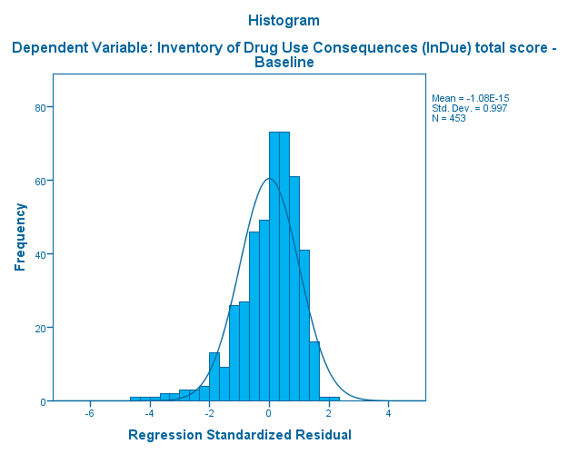

Charts  
Charts - *zresid Normal P-P Plot - November 15, 2017

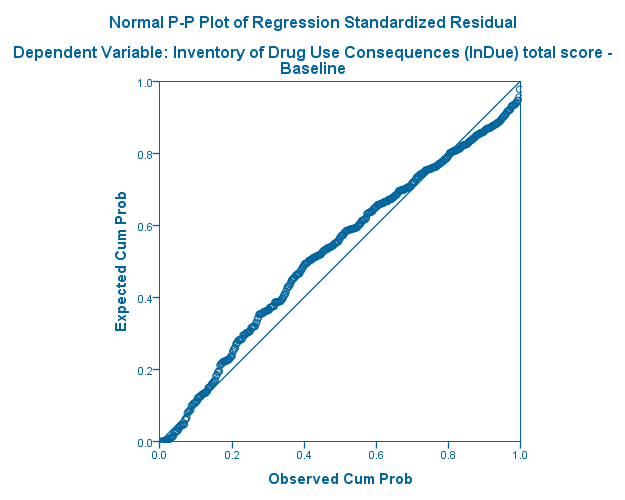

Log  
Log - Log - November 15, 2017

* ============================================.  
* ANCOVA using a regression approach  
* DV = indtot; IV = mcs; CV = female  
*  
* put in main effect for mcsC  
* then add covariate male  
* and then test for homogenity of slopes - add in interaction term  
* ============================================.  
REGRESSION  
/DESCRIPTIVES MEAN STDDEV CORR SIG N  
/MISSING LISTWISE  
/STATISTICS COEFF OUTS CI(95) R ANOVA COLLIN TOL CHANGE ZPP  
/CRITERIA=PIN(.05) POUT(.10)  
/NOORIGIN  
/DEPENDENT indtot  
/METHOD=ENTER mcsC  
/METHOD=ENTER male  
/METHOD=ENTER mcsC_x_male  
/RESIDUALS HISTOGRAM(ZRESID) NORMPROB(ZRESID).

Regression  
Regression - Descriptive Statistics - November 15, 2017

Descriptive StatisticsDescriptive Statistics, table, 1 levels of column headers and 1 levels of row headers, table with 4 columns and 6 rows

|  | Mean | Std. Deviation | N |
| --- | --- | --- | --- |
| indtot Inventory of Drug Use Consequences (InDue) total score - Baseline | 35.73 | 7.152 | 453 |
| mcsC | -.0003 | 12.83934 | 453 |
| male | .7638 | .42522 | 453 |
| mcsC_x_male | .6464 | 11.24991 | 453 |

Regression  
Regression - Correlations - November 15, 2017

CorrelationsCorrelations, table, 1 levels of column headers and 2 levels of row headers, table with 6 columns and 14 rows

|  |  | indtot Inventory of Drug Use Consequences (InDue) total score - Baseline | mcsC | male | mcsC_x_male |
| --- | --- | --- | --- | --- | --- |
| Pearson Correlation | indtot Inventory of Drug Use Consequences (InDue) total score - Baseline | 1.000 | -.381 | .261 | -.315 |
|  | mcsC | -.381 | 1.000 | .119 | .879 |
|  | male | .261 | .119 | 1.000 | .032 |
|  | mcsC_x_male | -.315 | .879 | .032 | 1.000 |
| Sig. (1-tailed) | indtot Inventory of Drug Use Consequences (InDue) total score - Baseline | . | .000 | .000 | .000 |
|  | mcsC | .000 | . | .006 | .000 |
|  | male | .000 | .006 | . | .249 |
|  | mcsC_x_male | .000 | .000 | .249 | . |
| N | indtot Inventory of Drug Use Consequences (InDue) total score - Baseline | 453 | 453 | 453 | 453 |
|  | mcsC | 453 | 453 | 453 | 453 |
|  | male | 453 | 453 | 453 | 453 |
|  | mcsC_x_male | 453 | 453 | 453 | 453 |

Regression  
Regression - Variables Entered/Removed - November 15, 2017

Variables Entered/Removed<sup>a</sup>Variables Entered/Removed, table, 1 levels of column headers and 1 levels of row headers, table with 4 columns and 7 rows

| Model | Variables Entered | Variables Removed | Method |
| --- | --- | --- | --- |
| 1 | mcsC<sup>b</sup> | . | Enter |
| 2 | male<sup>b</sup> | . | Enter |
| 3 | mcsC_x_male<sup>b</sup> | . | Enter |

a. Dependent Variable: indtot Inventory of Drug Use Consequences (InDue) total score - Baseline  
b. All requested variables entered.

Regression  
Regression - Model Summary - November 15, 2017

Model Summary<sup>d</sup>Model Summary, table, 2 levels of column headers and 1 levels of row headers, table with 10 columns and 10 rows

| Model | R | R Square | Adjusted R Square | Std. Error of the Estimate | Change Statistics |  |  |  |  |
| --- | --- | --- | --- | --- | --- | --- | --- | --- | --- |
|  |  |  |  |  | R Square Change | F Change | df1 | df2 | Sig. F Change |
| 1 | .381<sup>a</sup> | .145 | .143 | 6.621 | .145 | 76.407 | 1 | 451 | .000 |
| 2 | .490<sup>b</sup> | .240 | .237 | 6.249 | .095 | 56.349 | 1 | 450 | .000 |
| 3 | .498<sup>c</sup> | .248 | .243 | 6.224 | .008 | 4.655 | 1 | 449 | .031 |

a. Predictors: (Constant), mcsC  
b. Predictors: (Constant), mcsC, male  
c. Predictors: (Constant), mcsC, male, mcsC_x_male  
d. Dependent Variable: indtot Inventory of Drug Use Consequences (InDue) total score - Baseline

Regression  
Regression - ANOVA - November 15, 2017

ANOVA<sup>a</sup>ANOVA, table, 1 levels of column headers and 2 levels of row headers, table with 7 columns and 15 rows

| Model |  | Sum of Squares | df | Mean Square | F | Sig. |
| --- | --- | --- | --- | --- | --- | --- |
| 1 | Regression | 3349.702 | 1 | 3349.702 | 76.407 | .000<sup>b</sup> |
|  | Residual | 19771.900 | 451 | 43.840 |  |  |
|  | Total | 23121.603 | 452 |  |  |  |
| 2 | Regression | 5550.014 | 2 | 2775.007 | 71.067 | .000<sup>c</sup> |
|  | Residual | 17571.589 | 450 | 39.048 |  |  |
|  | Total | 23121.603 | 452 |  |  |  |
| 3 | Regression | 5730.320 | 3 | 1910.107 | 49.314 | .000<sup>d</sup> |
|  | Residual | 17391.282 | 449 | 38.733 |  |  |
|  | Total | 23121.603 | 452 |  |  |  |

a. Dependent Variable: indtot Inventory of Drug Use Consequences (InDue) total score - Baseline  
b. Predictors: (Constant), mcsC  
c. Predictors: (Constant), mcsC, male  
d. Predictors: (Constant), mcsC, male, mcsC_x_male

Regression  
Regression - Coefficients - November 15, 2017

Coefficients<sup>a</sup>Coefficients, table, 2 levels of column headers and 2 levels of row headers, table with 14 columns and 13 rows

| Model |  | Unstandardized Coefficients |  | Standardized Coefficients | t | Sig. | 95.0% Confidence Interval for B |  | Correlations |  |  | Collinearity Statistics |  |
| --- | --- | --- | --- | --- | --- | --- | --- | --- | --- | --- | --- | --- | --- |
|  |  | B | Std. Error | Beta |  |  | Lower Bound | Upper Bound | Zero-order | Partial | Part | Tolerance | VIF |
| 1 | (Constant) | 35.728 | .311 |  | 114.849 | .000 | 35.117 | 36.340 |  |  |  |  |  |
|  | mcsC | -.212 | .024 | -.381 | -8.741 | .000 | -.260 | -.164 | -.381 | -.381 | -.381 | 1.000 | 1.000 |
| 2 | (Constant) | 31.737 | .607 |  | 52.252 | .000 | 30.543 | 32.931 |  |  |  |  |  |
|  | mcsC | -.233 | .023 | -.418 | -10.088 | .000 | -.278 | -.187 | -.381 | -.429 | -.415 | .986 | 1.014 |
|  | male | 5.226 | .696 | .311 | 7.507 | .000 | 3.858 | 6.594 | .261 | .334 | .308 | .986 | 1.014 |
| 3 | (Constant) | 31.483 | .616 |  | 51.086 | .000 | 30.272 | 32.694 |  |  |  |  |  |
|  | mcsC | -.325 | .049 | -.584 | -6.676 | .000 | -.421 | -.230 | -.381 | -.301 | -.273 | .219 | 4.567 |
|  | male | 5.457 | .702 | .324 | 7.778 | .000 | 4.078 | 6.836 | .261 | .345 | .318 | .963 | 1.039 |
|  | mcsC_x_male | .119 | .055 | .187 | 2.158 | .031 | .011 | .228 | -.315 | .101 | .088 | .222 | 4.507 |

a. Dependent Variable: indtot Inventory of Drug Use Consequences (InDue) total score - Baseline

Regression  
Regression - Excluded Variables - November 15, 2017

Excluded Variables<sup>a</sup>Excluded Variables, table, 2 levels of column headers and 2 levels of row headers, table with 9 columns and 9 rows

| Model |  | Beta In | t | Sig. | Partial Correlation | Collinearity Statistics |  |  |
| --- | --- | --- | --- | --- | --- | --- | --- | --- |
|  |  |  |  |  |  | Tolerance | VIF | Minimum Tolerance |
| 1 | male | .311<sup>b</sup> | 7.507 | .000 | .334 | .986 | 1.014 | .986 |
|  | mcsC_x_male | .084<sup>b</sup> | .921 | .358 | .043 | .227 | 4.402 | .227 |
| 2 | mcsC_x_male | .187<sup>c</sup> | 2.158 | .031 | .101 | .222 | 4.507 | .219 |

a. Dependent Variable: indtot Inventory of Drug Use Consequences (InDue) total score - Baseline  
b. Predictors in the Model: (Constant), mcsC  
c. Predictors in the Model: (Constant), mcsC, male

Regression  
Regression - Collinearity Diagnostics - November 15, 2017

Collinearity Diagnostics<sup>a</sup>Collinearity Diagnostics, table, 2 levels of column headers and 2 levels of row headers, table with 8 columns and 13 rows

| Model | Dimension | Eigenvalue | Condition Index | Variance Proportions |  |  |  |
| --- | --- | --- | --- | --- | --- | --- | --- |
|  |  |  |  | (Constant) | mcsC | male | mcsC_x_male |
| 1 | 1 | 1.000 | 1.000 | .50 | .50 |  |  |
|  | 2 | 1.000 | 1.000 | .50 | .50 |  |  |
| 2 | 1 | 1.876 | 1.000 | .06 | .00 | .06 |  |
|  | 2 | 1.000 | 1.370 | .00 | .98 | .00 |  |
|  | 3 | .124 | 3.887 | .94 | .02 | .94 |  |
| 3 | 1 | 1.967 | 1.000 | .03 | .03 | .03 | .03 |
|  | 2 | 1.786 | 1.049 | .03 | .03 | .03 | .03 |
|  | 3 | .148 | 3.642 | .39 | .33 | .43 | .36 |
|  | 4 | .099 | 4.461 | .55 | .61 | .51 | .58 |

a. Dependent Variable: indtot Inventory of Drug Use Consequences (InDue) total score - Baseline

Regression  
Regression - Residuals Statistics - November 15, 2017

Residuals Statistics<sup>a</sup>Residuals Statistics, table, 1 levels of column headers and 1 levels of row headers, table with 6 columns and 7 rows

|  | Minimum | Maximum | Mean | Std. Deviation | N |
| --- | --- | --- | --- | --- | --- |
| Predicted Value | 22.09 | 42.08 | 35.73 | 3.561 | 453 |
| Residual | -28.555 | 12.487 | .000 | 6.203 | 453 |
| Std. Predicted Value | -3.829 | 1.782 | .000 | 1.000 | 453 |
| Std. Residual | -4.588 | 2.006 | .000 | .997 | 453 |

a. Dependent Variable: indtot Inventory of Drug Use Consequences (InDue) total score - Baseline

Charts  
Charts - *zresid Histogram - November 15, 2017

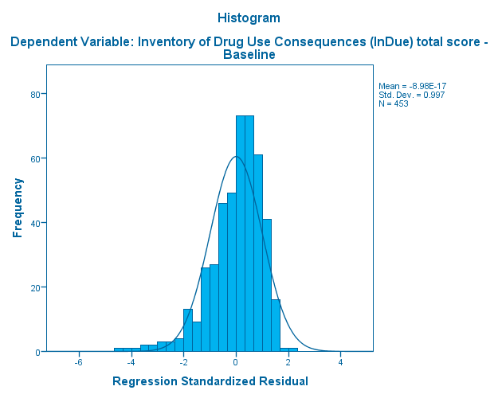

Charts  
Charts - *zresid Normal P-P Plot - November 15, 2017

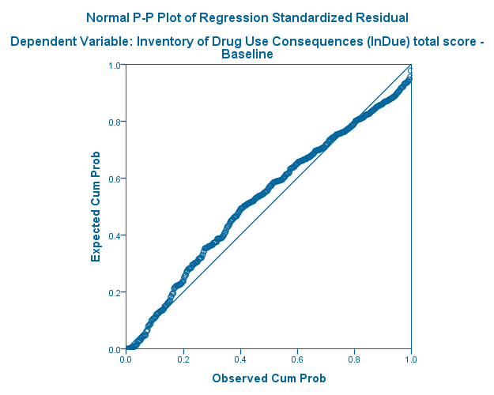

Log  
Log - Log - November 15, 2017

* ============================================.  
* Make a plot of the potential interaction between  
* mcs and female  
* ============================================.  
GRAPH  
/SCATTERPLOT(BIVAR)=mcs WITH indtot  
/PANEL COLVAR=female COLOP=CROSS  
/MISSING=LISTWISE.

Graph  
Graph - Scatter of indtot mcs - November 15, 2017

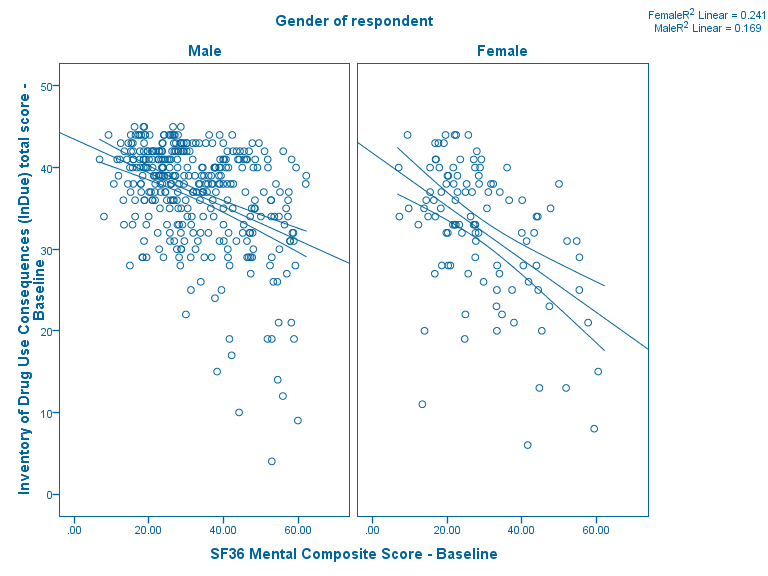

Log  
Log - Log - November 15, 2017

Between-Subjects FactorsBetween-Subjects Factors, table, 1 levels of column headers and 2 levels of row headers, table with 4 columns and 4 rows

|  |  | Value Label | N |
| --- | --- | --- | --- |
| female Gender of respondent | 0 | Male | 346 |
|  | 1 | Female | 107 |

Univariate Analysis of Variance  
Univariate Analysis of Variance - Descriptive Statistics - November 15, 2017

Descriptive StatisticsDescriptive Statistics, table, Dependent Variable, indtot Inventory of Drug Use Consequences (InDue) total score - Baseline, 1 layers, 1 levels of column headers and 1 levels of row headers, table with 4 columns and 6 rows

| indtot Inventory of Drug Use Consequences (InDue) total score - Baseline indtot Inventory of Drug Use Consequences (InDue) total score - Baseline |  |  |  |
| --- | --- | --- | --- |
| female Gender of respondent | Mean | Std. Deviation | N |
| 0 Male | 36.77 | 6.455 | 346 |
| 1 Female | 32.37 | 8.225 | 107 |
| Total | 35.73 | 7.152 | 453 |

Univariate Analysis of Variance  
Univariate Analysis of Variance - Levene's Test of Equality of Error Variances - November 15, 2017

Levene's Test of Equality of Error Variances<sup>a</sup>Levene's Test of Equality of Error Variances, table, Dependent Variable, indtot Inventory of Drug Use Consequences (InDue) total score - Baseline, 1 layers, 1 levels of column headers and 0 levels of row headers, table with 4 columns and 6 rows

| indtot Inventory of Drug Use Consequences (InDue) total score - Baseline indtot Inventory of Drug Use Consequences (InDue) total score - Baseline |  |  |  |
| --- | --- | --- | --- |
| F | df1 | df2 | Sig. |
| 7.210 | 1 | 451 | .008 |

Tests the null hypothesis that the error variance of the dependent variable is equal across groups.  
a. Design: Intercept + mcsC + female + female * mcsC

Univariate Analysis of Variance  
Univariate Analysis of Variance - Tests of Between-Subjects Effects - November 15, 2017

Tests of Between-Subjects EffectsTests of Between-Subjects Effects, table, Dependent Variable, indtot Inventory of Drug Use Consequences (InDue) total score - Baseline, 1 layers, 1 levels of column headers and 1 levels of row headers, table with 7 columns and 12 rows

| indtot Inventory of Drug Use Consequences (InDue) total score - Baseline indtot Inventory of Drug Use Consequences (InDue) total score - Baseline |  |  |  |  |  |  |
| --- | --- | --- | --- | --- | --- | --- |
| Source | Type III Sum of Squares | df | Mean Square | F | Sig. | Partial Eta Squared |
| Corrected Model | 5730.320<sup>a</sup> | 3 | 1910.107 | 49.314 | .000 | .248 |
| Intercept | 368411.090 | 1 | 368411.090 | 9511.465 | .000 | .955 |
| mcsC | 3583.807 | 1 | 3583.807 | 92.525 | .000 | .171 |
| female | 2343.445 | 1 | 2343.445 | 60.502 | .000 | .119 |
| female * mcsC | 180.306 | 1 | 180.306 | 4.655 | .031 | .010 |
| Error | 17391.282 | 449 | 38.733 |  |  |  |
| Total | 601387.000 | 453 |  |  |  |  |
| Corrected Total | 23121.603 | 452 |  |  |  |  |

a. R Squared = .248 (Adjusted R Squared = .243)

Univariate Analysis of Variance  
Univariate Analysis of Variance - Parameter Estimates - November 15, 2017

Parameter EstimatesParameter Estimates, table, Dependent Variable, indtot Inventory of Drug Use Consequences (InDue) total score - Baseline, 1 layers, 2 levels of column headers and 1 levels of row headers, table with 8 columns and 11 rows

| indtot Inventory of Drug Use Consequences (InDue) total score - Baseline indtot Inventory of Drug Use Consequences (InDue) total score - Baseline |  |  |  |  |  |  |  |  |
| --- | --- | --- | --- | --- | --- | --- | --- | --- |
| Parameter | B | Std. Error | t | Sig. | 95% Confidence Interval |  | Partial Eta Squared |  |
|  |  |  |  |  | Lower Bound | Upper Bound |  |  |
| Intercept | 31.483 | .616 | 51.086 | .000 | 30.272 | 32.694 |  | .853 |
| mcsC | -.325 | .049 | -6.676 | .000 | -.421 | -.230 | .090 |  |
| [female=0] | 5.457 | .702 | 7.778 | .000 | 4.078 | 6.836 | .119 |  |
| [female=1] | 0<sup>a</sup> | . | . | . | . | . | . |  |
| [female=0] * mcsC | .119 | .055 | 2.158 | .031 | .011 | .228 | .010 |  |
| [female=1] * mcsC | 0<sup>a</sup> | . | . | . | . | . | . |  |

a. This parameter is set to zero because it is redundant.

Estimated Marginal Means  
Estimated Marginal Means - 1. Grand Mean - November 15, 2017

1. Grand Mean1. Grand Mean, table, Dependent Variable, indtot Inventory of Drug Use Consequences (InDue) total score - Baseline, 1 layers, 2 levels of column headers and 0 levels of row headers, table with 4 columns and 6 rows

| indtot Inventory of Drug Use Consequences (InDue) total score - Baseline indtot Inventory of Drug Use Consequences (InDue) total score - Baseline |  |  |  |
| --- | --- | --- | --- |
| Mean | Std. Error | 95% Confidence Interval |  |
|  |  | Lower Bound | Upper Bound |
| 34.212<sup>a</sup> | .351 | 33.522 | 34.901 |

a. Covariates appearing in the model are evaluated at the following values: mcsC = -.0003.

Estimated Marginal Means  
Estimated Marginal Means - 2. Gender of respondent - November 15, 2017

2. Gender of respondent2. Gender of respondent, table, Dependent Variable, indtot Inventory of Drug Use Consequences (InDue) total score - Baseline, 1 layers, 2 levels of column headers and 1 levels of row headers, table with 5 columns and 7 rows

| indtot Inventory of Drug Use Consequences (InDue) total score - Baseline indtot Inventory of Drug Use Consequences (InDue) total score - Baseline |  |  |  |  |
| --- | --- | --- | --- | --- |
| Gender of respondent | Mean | Std. Error | 95% Confidence Interval |  |
|  |  |  | Lower Bound | Upper Bound |
| 0 Male | 36.940<sup>a</sup> | .335 | 36.281 | 37.599 |
| 1 Female | 31.483<sup>a</sup> | .616 | 30.272 | 32.694 |

a. Covariates appearing in the model are evaluated at the following values: mcsC = -.0003.

Log  
Log - Log - November 15, 2017

UNIANOVA indtot BY male WITH mcsC  
/METHOD=SSTYPE(3)  
/INTERCEPT=INCLUDE  
/EMMEANS=TABLES(OVERALL) WITH(mcsC=MEAN)  
/EMMEANS=TABLES(male) WITH(mcsC=MEAN)  
/PRINT=PARAMETER ETASQ HOMOGENEITY DESCRIPTIVE  
/CRITERIA=ALPHA(.05)  
/DESIGN=mcsC male male*mcsC.

Univariate Analysis of Variance  
Univariate Analysis of Variance - Between-Subjects Factors - November 15, 2017

Between-Subjects FactorsBetween-Subjects Factors, table, 1 levels of column headers and 2 levels of row headers, table with 3 columns and 4 rows

|  |  | N |
| --- | --- | --- |
| male | .00 | 107 |
|  | 1.00 | 346 |

Univariate Analysis of Variance  
Univariate Analysis of Variance - Descriptive Statistics - November 15, 2017

Descriptive StatisticsDescriptive Statistics, table, Dependent Variable, indtot Inventory of Drug Use Consequences (InDue) total score - Baseline, 1 layers, 1 levels of column headers and 1 levels of row headers, table with 4 columns and 6 rows

| indtot Inventory of Drug Use Consequences (InDue) total score - Baseline indtot Inventory of Drug Use Consequences (InDue) total score - Baseline |  |  |  |
| --- | --- | --- | --- |
| male | Mean | Std. Deviation | N |
| .00 | 32.37 | 8.225 | 107 |
| 1.00 | 36.77 | 6.455 | 346 |
| Total | 35.73 | 7.152 | 453 |

Univariate Analysis of Variance  
Univariate Analysis of Variance - Levene's Test of Equality of Error Variances - November 15, 2017

Levene's Test of Equality of Error Variances<sup>a</sup>Levene's Test of Equality of Error Variances, table, Dependent Variable, indtot Inventory of Drug Use Consequences (InDue) total score - Baseline, 1 layers, 1 levels of column headers and 0 levels of row headers, table with 4 columns and 6 rows

| indtot Inventory of Drug Use Consequences (InDue) total score - Baseline indtot Inventory of Drug Use Consequences (InDue) total score - Baseline |  |  |  |
| --- | --- | --- | --- |
| F | df1 | df2 | Sig. |
| 7.210 | 1 | 451 | .008 |

Tests the null hypothesis that the error variance of the dependent variable is equal across groups.  
a. Design: Intercept + mcsC + male + male * mcsC

Univariate Analysis of Variance  
Univariate Analysis of Variance - Tests of Between-Subjects Effects - November 15, 2017

Tests of Between-Subjects EffectsTests of Between-Subjects Effects, table, Dependent Variable, indtot Inventory of Drug Use Consequences (InDue) total score - Baseline, 1 layers, 1 levels of column headers and 1 levels of row headers, table with 7 columns and 12 rows

| indtot Inventory of Drug Use Consequences (InDue) total score - Baseline indtot Inventory of Drug Use Consequences (InDue) total score - Baseline |  |  |  |  |  |  |
| --- | --- | --- | --- | --- | --- | --- |
| Source | Type III Sum of Squares | df | Mean Square | F | Sig. | Partial Eta Squared |
| Corrected Model | 5730.320<sup>a</sup> | 3 | 1910.107 | 49.314 | .000 | .248 |
| Intercept | 368411.090 | 1 | 368411.090 | 9511.465 | .000 | .955 |
| mcsC | 3583.807 | 1 | 3583.807 | 92.525 | .000 | .171 |
| male | 2343.445 | 1 | 2343.445 | 60.502 | .000 | .119 |
| male * mcsC | 180.306 | 1 | 180.306 | 4.655 | .031 | .010 |
| Error | 17391.282 | 449 | 38.733 |  |  |  |
| Total | 601387.000 | 453 |  |  |  |  |
| Corrected Total | 23121.603 | 452 |  |  |  |  |

a. R Squared = .248 (Adjusted R Squared = .243)

Univariate Analysis of Variance  
Univariate Analysis of Variance - Parameter Estimates - November 15, 2017

Parameter EstimatesParameter Estimates, table, Dependent Variable, indtot Inventory of Drug Use Consequences (InDue) total score - Baseline, 1 layers, 2 levels of column headers and 1 levels of row headers, table with 8 columns and 11 rows

| indtot Inventory of Drug Use Consequences (InDue) total score - Baseline indtot Inventory of Drug Use Consequences (InDue) total score - Baseline |  |  |  |  |  |  |  |  |
| --- | --- | --- | --- | --- | --- | --- | --- | --- |
| Parameter | B | Std. Error | t | Sig. | 95% Confidence Interval |  | Partial Eta Squared |  |
|  |  |  |  |  | Lower Bound | Upper Bound |  |  |
| Intercept | 36.940 | .335 | 110.168 | .000 | 36.281 | 37.599 |  | .964 |
| mcsC | -.206 | .026 | -7.916 | .000 | -.257 | -.155 | .122 |  |
| [male=.00] | -5.457 | .702 | -7.778 | .000 | -6.836 | -4.078 | .119 |  |
| [male=1.00] | 0<sup>a</sup> | . | . | . | . | . | . |  |
| [male=.00] * mcsC | -.119 | .055 | -2.158 | .031 | -.228 | -.011 | .010 |  |
| [male=1.00] * mcsC | 0<sup>a</sup> | . | . | . | . | . | . |  |

a. This parameter is set to zero because it is redundant.

Estimated Marginal Means  
Estimated Marginal Means - 1. Grand Mean - November 15, 2017

1. Grand Mean1. Grand Mean, table, Dependent Variable, indtot Inventory of Drug Use Consequences (InDue) total score - Baseline, 1 layers, 2 levels of column headers and 0 levels of row headers, table with 4 columns and 6 rows

| indtot Inventory of Drug Use Consequences (InDue) total score - Baseline indtot Inventory of Drug Use Consequences (InDue) total score - Baseline |  |  |  |
| --- | --- | --- | --- |
| Mean | Std. Error | 95% Confidence Interval |  |
|  |  | Lower Bound | Upper Bound |
| 34.212<sup>a</sup> | .351 | 33.522 | 34.901 |

a. Covariates appearing in the model are evaluated at the following values: mcsC = -.0003.

Estimated Marginal Means  
Estimated Marginal Means - 2. male - November 15, 2017

2. male2. male, table, Dependent Variable, indtot Inventory of Drug Use Consequences (InDue) total score - Baseline, 1 layers, 2 levels of column headers and 1 levels of row headers, table with 5 columns and 7 rows

| indtot Inventory of Drug Use Consequences (InDue) total score - Baseline indtot Inventory of Drug Use Consequences (InDue) total score - Baseline |  |  |  |  |
| --- | --- | --- | --- | --- |
| male | Mean | Std. Error | 95% Confidence Interval |  |
|  |  |  | Lower Bound | Upper Bound |
| .00 | 31.483<sup>a</sup> | .616 | 30.272 | 32.694 |
| 1.00 | 36.940<sup>a</sup> | .335 | 36.281 | 37.599 |

a. Covariates appearing in the model are evaluated at the following values: mcsC = -.0003.

Log  
Log - Log - November 15, 2017

* ============================================.  
* pay CLOSE attention to the differences between the  
* Tests of Between-Subjects Effects  
* and the Parameter Estimates tables  
* ============================================.

[output not shown]

[output not shown]

[output not shown]

[output not shown]

[output not shown]

[output not shown]